# Лабораторная работа №8

Операционные системы

Дворкина Ева Владимировна

Российский университет дружбы народов, Москва, Россия

19 марта 2023

## Докладчик

- Дворкина Ева Владимировна
- студентка из группы НКАбд-01-22
- Факультет физико-математических и естественных наук
- Российский университет дружбы народов
- 1132226447@rudn.ru
- https:///evdvorkina.github.io

## Цель работы

Цель данной лабораторной работы - познакомиться с операционной системой Linux, получить практические навыки работы с редактором vi, установленным по умолчанию практически во всех дистрибутивах.

## Задание

1. Ознакомиться с теоретическим материалом.
2. Ознакомиться с редактором vi.
3. Выполнить упражнения, используя команды vi.

## Выполнение лабораторной работы

Создаю директорию, в которой буду работать, с помощью команды mkdir, перехожу в нее с помощью команды cd, создаю и открываю для редактирования файл с помощью встроенного текстового редактора vi

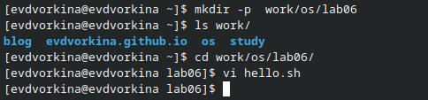

Создание файла через vi

## Выполнение лабораторной работы

Нажимаю i, чтобы начать редактирование и добавляться текст (режим добавления), далее добавляю текст.

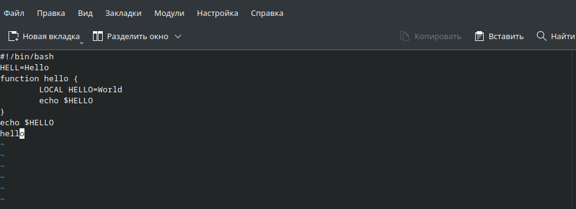

Запись в файл

## Выполнение лабораторной работы

Нажимаю esc, чтобы выйти из режима добавления и перейти в командный режим. Перехожу в режим последней строки.

[figure not shown]

Режим последней строки

## Выполнение лабораторной работы

Ввожу w для сохранения и q для выхода и нажимаю enter, после чего файл сохраняется с изменениями и я возвращаюсь в терминал.

## Выполнение лабораторной работы

С помощью chmod добавляю права на исполнение файла, делая его исполняемым.

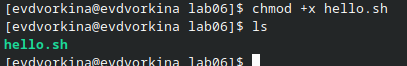

Обновление прав

## Выполнение лабораторной работы

Снова открываю этот файл с помощью текстового редактора vi.

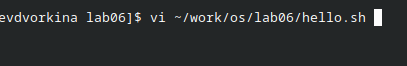

Открытие с помощью текстового редактора

## Выполнение лабораторной работы

Изменяю местоположение курсора.

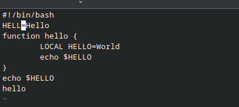

Редактирование файла

## Выполнение лабораторной работы

В режиме добавления (клавиша i) удаляю слово LOCAL, снова перехожу в командный режим с помощью esc.

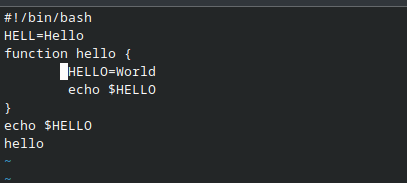

Редактирование файла

## Выполнение лабораторной работы

В режиме добавления (клавиша i) добавляю слово local, снова перехожу в командный режим с помощью esc.

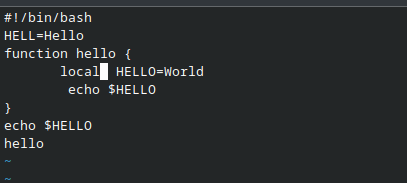

Редактирование файла

## Выполнение лабораторной работы

В режиме добавления (клавиша i) перехожу в конец последней строки и добавляю новую строку, снова перехожу в командный режим с помощью esc. После этого я вернулась в режим добавления, удалила строку и вернулась в командный режим.

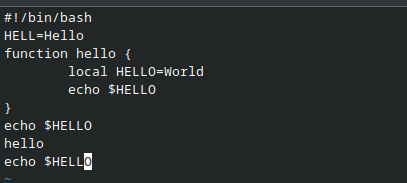

Редактирование файла

## Выполнение лабораторной работы

В командном режиме я нажала “u” и отменила последнее действие, удаление строки.

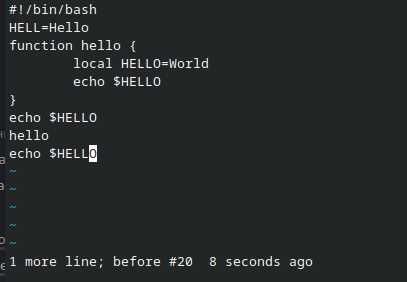

Отмена последнего действия

## Выполнение лабораторной работы

Перешла в режим последней строки и ввела w для сохранения файла и q для выхода, нажала enter и файл закрылся.

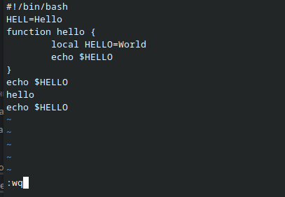

Сохранение и выход

## Выводы

При выполнении данной лабораторной работы я познакомилась с операционной системой Linux, получила практические навыки работы с редактором vi, установленным по умолчанию практически во всех дистрибутивах.